# Analyze and Visualize Important QOIs

## 🎯 Estimate Corrected MMs or AMCEs

In conjoint analysis, default MMs and AMCEs can be **biased** due to measurement error from intra-respondent variability.

**projoint** corrects for this bias automatically.

The following instructions apply to choice-level data. What if you have profile-level data?<sup>ⓘ</sup> Our FAQ Page has instructions to estimate and visualize profile-level QOIs.

## 📦 Prepare Example Data

> **Outcome naming & order (important)**
> - List `.outcomes` in the **order questions were asked**.
> - If you have a repeated task, its outcome must be the **last element**.
> - For base tasks (all but last), the function reads the **digits** in each name as the task id (e.g., `"choice4"`, `"Q4"`, `"task04"` → task 4).
> - The **repeated base task** is inferred from the **first base outcome’s digits**. The repeated outcome itself **need not** contain digits—only its position (last) matters.
> - Outcome strings must end with verified choice labels. Prefer an explicit map using the complete exported response values, such as `.choice_map = c("Community A" = 1, "Community B" = 2)`. The names are the response values; `1` and `2` are the Qualtrics profile positions. Verify this relationship from the survey instrument or QSF file because it cannot be inferred from the CSV.
> - Invalid labels, trailing whitespace, and missing choices stop with an informative error. Use `.allow_missing_choices = TRUE` only after review.

**Examples**

```r
# Standard order; repeated = task 1
data("exampleData1")
outcomes <- c(paste0("choice", 1:8), "choice1_repeated_flipped")
out1 <- reshape_projoint(
  exampleData1,
  outcomes,
  .choice_map = c("Community A" = 1, "Community B" = 2)
)
```

## 🛠️ Why Use IDs (e.g., `att1`, `level1`)?

Before estimating quantities, it’s important to understand how attribute and level IDs work inside projoint.

We recommend working with **attribute IDs** rather than actual text labels because:

- Safer against special characters, languages, or typos
- Allows **multiple attributes** to have identical labels (e.g., “High” for both “Teaching Quality” and “Research Quality”)

Check attribute-level mappings:

```r
out1$labels
```

```
## # A tibble: 24 × 4
##    attribute                level                        attribute_id level_id
##    <chr>                    <chr>                        <chr>        <chr>
##  1 Housing Cost             15% of pre-tax income        att1         att1:leve…
##  2 Housing Cost             30% of pre-tax income        att1         att1:leve…
##  3 Housing Cost             40% of pre-tax income        att1         att1:leve…
##  4 Presidential Vote (2020) 30% Democrat, 70% Republican att2         att2:leve…
##  5 Presidential Vote (2020) 50% Democrat, 50% Republican att2         att2:leve…
##  6 Presidential Vote (2020) 70% Democrat, 30% Republican att2         att2:leve…
##  7 Racial Composition       50% White, 50% Nonwhite      att3         att3:leve…
##  8 Racial Composition       75% White, 25% Nonwhite      att3         att3:leve…
##  9 Racial Composition       90% White, 10% Nonwhite      att3         att3:leve…
## 10 Racial Composition       96% White, 4% Nonwhite       att3         att3:leve…
## # ℹ 14 more rows
```

You can also save these labels for easier editing:

```r
save_labels(out1, "labels.csv")
```

## 📈 Estimate Marginal Means (MMs)

**Choice-Level MMs (Specific Level)**

Suppose you want to estimate, within a given profile pair, the probability of choosing a profile that includes “40% of pre-tax income” (`level3`) for Housing Cost (`att1`) rather than one that includes “15% of pre-tax income” (`level1`) for the same attribute, averaging over all combinations of the other attributes and across respondents; then use the following code:

```r
qoi <- set_qoi(
  .structure = "choice_level",
  .att_choose = "att1",
  .lev_choose = "level3",
  .att_notchoose = "att1",
  .lev_notchoose = "level1"
)

mm2 <- projoint(out1, qoi)
print(mm2)
```

```
##
## Projoint results object
## -------------------------
## Estimand:  mm
## Structure:  choice_level
## Standard error method:  analytical
## IRR:  Estimated
## Tau:  0.172
## Number of estimates:  2
```

```r
summary(mm2)
```

```
##
## Summary of Projoint Estimates
## ------------------------------
## Estimand: mm
## Structure: choice_level
## Standard error method: analytical
## SE type (lm_robust):   CR2 (clustered by id)
## IRR: Estimated
## Tau: 0.172
```

```
## # A tibble: 2 × 7
##   estimand       estimate     se conf.low conf.high att_level_choose
##   <chr>             <dbl>  <dbl>    <dbl>     <dbl> <chr>
## 1 mm_uncorrected    0.419 0.0197    0.380     0.458 att1:level3
## 2 mm_corrected      0.376 0.0308    0.316     0.437 att1:level3
## # ℹ 1 more variable: att_level_notchoose <chr>
```

## 📉 Estimate AMCEs

**Choice-Level AMCEs (Specific Level)**

Suppose you want to quantify how the choice probability **changes** between the following profile pairs:

- choosing a profile that includes “40% of pre-tax income” (`level3`) for Housing Cost (`att1`) versus one that includes “15% of pre-tax income” (`level1`) for Housing Cost (`att1`); **and**
- [baseline] choosing a profile that includes “30% of pre-tax income” (`level2`) for Housing Cost (`att1`) versus one that includes “15% of pre-tax income” (`level1`) for Housing Cost (`att1`);

averaging over all combinations of the other attributes and across respondents. Then write the following code:

```r
qoi <- set_qoi(
  .structure = "choice_level",
  .estimand = "amce",
  .att_choose = "att1",
  .lev_choose = "level3",
  .att_notchoose = "att1",
  .lev_notchoose = "level1",
  .att_choose_b = "att1",
  .lev_choose_b = "level2",
  .att_notchoose_b = "att1",
  .lev_notchoose_b = "level1"
)

amce2 <- projoint(out1, qoi)
print(amce2)
```

```
##
## Projoint results object
## -------------------------
## Estimand:  amce
## Structure:  choice_level
## Standard error method:  analytical
## IRR:  Estimated
## Tau:  0.172
## Number of estimates:  2
```

```r
summary(amce2)
```

```
##
## Summary of Projoint Estimates
## ------------------------------
## Estimand: amce
## Structure: choice_level
## Standard error method: analytical
## SE type (lm_robust):   CR2 (clustered by id)
## IRR: Estimated
## Tau: 0.172
```

```
## # A tibble: 2 × 9
##   estimand         estimate     se conf.low conf.high att_level_choose
##   <chr>               <dbl>  <dbl>    <dbl>     <dbl> <chr>
## 1 amce_uncorrected  -0.0135 0.0269  -0.0665    0.0394 att1:level3
## 2 amce_corrected    -0.0206 0.0412  -0.102     0.0604 att1:level3
## # ℹ 3 more variables: att_level_notchoose <chr>,
## #   att_level_choose_baseline <chr>, att_level_notchoose_baseline <chr>
```

## 🔎 Predict Intra-Respondent Reliability (IRR)

If your design **does not include** a repeated task, you can **predict** IRR using predict_tau(), based on observed respondent behavior.

**Predict IRR Using `predict_tau()`**

```r
data(out1_arranged)
predicted_irr <- predict_tau(out1_arranged)

print(predicted_irr)
```

```
## Tau estimated using the extrapolation method: 0.743
```

```r
summary(predicted_irr)
```

```
## # A tibble: 8 × 2
##       x predicted
##   <int>     <dbl>
## 1     0     0.743
## 2     1     0.709
## 3     2     0.675
## 4     3     0.640
## 5     4     0.606
## 6     5     0.572
## 7     6     0.537
## 8     7     0.503
```

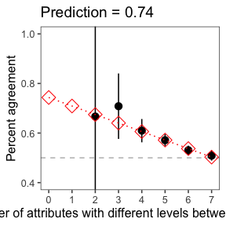

```r
plot(predicted_irr)
```

## 🎨 Visualize MMs or AMCEs

The **projoint** package provides ready-to-publish plotting tools for conjoint analysis results.

**Note:** The current version of **projoint** supports plotting choice-level MMs only.  
Support for **choice-level AMCEs** will be available in future updates!

### ⚖️ Choice-Level Analysis

**Estimate**

- Specify your quantity of interest:

```r
qoi_mm <- set_qoi(
  .structure = "choice_level", # default
  .att_choose = "att1",
  .lev_choose = "level1",
  .att_notchoose = "att1",
  .lev_notchoose = "level3"
)
```

- Estimate

```r
choice_mm <- projoint(
  .data = out1_arranged,
  .qoi = qoi_mm,
  .ignore_position = TRUE
)
```

**Visualize (Levels)**

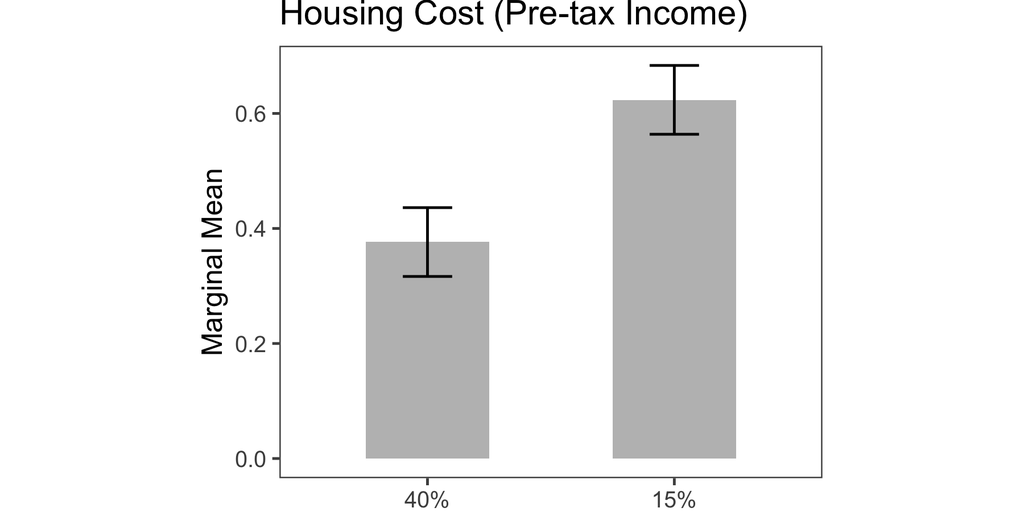

```r
plot(choice_mm)
```

**Visualize (Differences)**

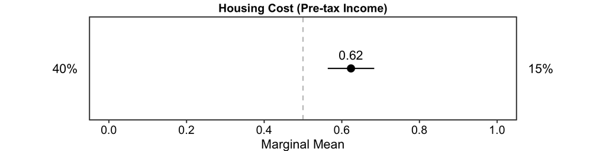

```r
plot(choice_mm, .type = "pointrange")
```

🏠 **Home:** [Home](https://yhoriuchi.github.io/projoint/index.html)